# MIDI-MT - Файлы конфигурации приложения

MIDI-MT Документация на Русском языке

### Файл конфигурации

- Секция общей конфигурации
- Настройки модулей
- Секция конфигурации элементов управления “units”
- Пример конфигурации элементов управления

Файл конфигурации имеет популярный Json формат и для его изменения можно воспользоваться любым текстовым редактором. Рабочий пример [конфигурационного файла](https://raw.githubusercontent.com/ClaudiaCoord/MIDI-EasyControl-to-Mackie-translator-for-Premiere-Pro/main/docs/Dist/MidiController.cnf) также входит в дистрибутив. Найти его вы можете в папке установки приложения, копия настроенной конфигурации находиться в под-папке **docs** с именем «**MidiController.cnf**».

Основные параметры файла конфигурации можно настроить из запускаемого диалога при выборе пункта меню «**Старт**». Вы также можете настроить эти параметры непосредственно при редактировании файла конфигурации.

### Секция общей конфигурации

```yaml
{
  "config": {
    "name": "MidiController",
    "autostart": true,
    "build": "1.0.6.3"
  },
  "units":[... описание элементов управления контроллера...]
}
```

Более подробно значения глобальных параметров и их взаимосвязь описаны в разделе Настройки

### Настройки модулей

Вся информация о настройке модулей находится в общем конфигурационном файле. Также, возможно жёстко переопределить настройку конкретного модуля, расположив одноименный с модулем файл настроек с расширением `.json` в том же каталоге. Пример на картинке ниже.

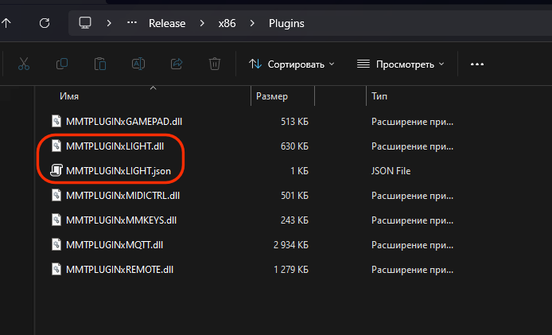

JSON секции настроек модулей находяться в описании самих модулей.

### Секция конфигурации элементов управления “units”

Строка описания элемента управления выглядит следующим образом:

```yaml
{
    "scene":177,       // сцена контрола
    "id":22,           // номер контрола
    "type":1,          // тип контрола
    "target":254,      // группа | назначение
    "longtarget":12,   // назначение
    "onoff": false,    // последние значение
    "value": 2,        // последние значение
    "apps": [          // список приложений для управления Аудио сессиями
       "App1",
       "App2"
    ]
}
```

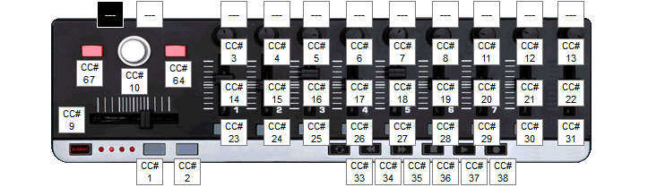

**Сцена (scene)**, в конфигурации указывается реальный Scene MIDI ID.  
Сцена это выбранный пресет, в типовом контроллере как правило 4 сцены:

| MIDI ID | Сцена | примечание |
| --- | --- | --- |
| 176 | 1 | нет |
| 177 | 2 | нет |
| 178 | 3 | нет |
| 179 | 4 | нет |
| 192 | 1 | для контрола JOG |
| 193 | 2 | для контрола JOG |
| 194 | 3 | для контрола JOG |
| 211 | 4 | для контрола JOG |
| 243 | 4 | для двух верхних кнопок по бокам JOG |
| 255 | - | сцена не выбрана |

**ID (id)**, MIDI идентификатор контрола, тут надеюсь всё понятно.

| MIDI ID | возможные значения |
| --- | --- |
| 9 | ползунок A-B, фиксированное значение |
| 10 | валкодер JOG, фиксированное значение |
| 64 | правая кнопка от валкодера, фиксированное значение |
| 67 | левая кнопка от валкодера, фиксированное значение |
| 0 - 170 | любые значения в этом диапазоне |
| 170 - 248 | используются для обозначения сцен |
| 249 - 254 | используются для обозначения групп |
| 255 | не определено |

**Тип (type)** контрола:

| № | тип контрола | enum |
| --- | --- | --- |
| 0 | круговой потенциометр | FADER |
| 1 | потенциометр “ползунок” | SLIDER |
| 2 | JOG, валкодер | KNOB |
| 3 | кнопка | BUTTON |
| 4 | кнопка с включенным режимом toggle | BUTTON TOGGLE |
| 5 | JOG, валкодер, инверсия направлений | KNOB INVERSE |
| 6 | круговой потенциометр, инверсия | FADER INVERSE |
| 7 | потенциометр “ползунок”, инверсия | SLIDER INVERSE |
| 255 | не определено | - |

**Назначение (target,longtarget)**, назначение полезной нагрузки контрола.  
Для кнопок, первое значение, **target** - это быстрое нажатие, второе значение, **longtarget** - длинное нажатие. Если нет необходимости использовать длинное нажатие, присвойте свойству **longtarget** значение `255`. Для других типов контролов, второе значение не обрабатывается, но требует установленного значения.

| № | полезная нагрузка |
| --- | --- |
| 0 | аудио громкость (мастер) |
| 1 | аудио баланс, панорама (мастер) |
| 2 | аудио mute (мастер) |
| 3 | аудио solo (мастер) |
| 4 | JOG - видео покадровая перемотка |
| 5 - 13 | аудио громкость - каналы 1-9 |
| 14 - 22 | аудио баланс, панорама - каналы 1-9 |
| 23 - 31 | аудио Solo - каналы 1-9 |
| 32 - 40 | аудио Mute - каналы 1-9 |
| 41 - 49 | аудио Select - каналы 1-9 |
| 50 - 57 | функции F1-F8, стандартный режим работы кнопки |
| 58 - 65 | функции F1-F8, срабатывает пока кнопка удерживается |
| 66 | Rewind |
| 67 | Forward |
| 68 | Stop |
| 69 | Play |
| 70 | Record |
| 71 | Up |
| 72 | Down |
| 73 | Left |
| 74 | Right |
| 75 | Zoom |
| 76 | Scrub |
| 255 | элемент не выбран |

Также, значение **target** может обозначать отношение к группе, как в случаях с группами `Аудио сессии`, `Мультимедийные клавиши`, `Управление светом` и `Умный Дом`. В этом случае, значение **longtarget** определяет полезную нагрузку.

| № | группа |
| --- | --- |
| 249 | модуль управления сценариями |
| 250 | модуль управления светом 16 бит |
| 251 | модуль управления светом 8 бит |
| 252 | модуль Умный Дом |
| 253 | модуль Мультимедийные клавиши |
| 254 | модуль Аудио сессии |
| 255 | элемент не выбран |

### Рабочий пример конфигурации элементов управления

```yaml
{
    ....,
    /* настройка для сцены 2 */

    "units":[
        {"scene":177,"id":22,"type":0,"target":0,"longtarget":255},
        {"scene":177,"id":13,"type":1,"target":1,"longtarget":255},
        {"scene":177,"id":31,"type":3,"target":3,"longtarget":255},
    ]
}
```